# Historical and Projected Water Balance Report for Crystal Bench

Janelle Christensen, Mike Tercek, David Thoma, John Gross

8/3/2020

Water balance is the mathematical accounting of water input and movement through the environment. It accounts for water storage in different phases (ice, liquid) and loss to the atmosphere (gas) via evapotranspiration. Water balance integrates the interactions of temperature and precipitation to estimate water availability, movement to streams and ground water and use by plants. Water balance accounts for heat load on different aspects and water holding capacity of different soil types. Water balance represents the modification of regional weather and climate to represent the biophysical conditions at local scales. For these reasons, water balance is usually more strongly correlated with natural resource response (plant growth, stream flow, fire danger) than temperature or precipitation.

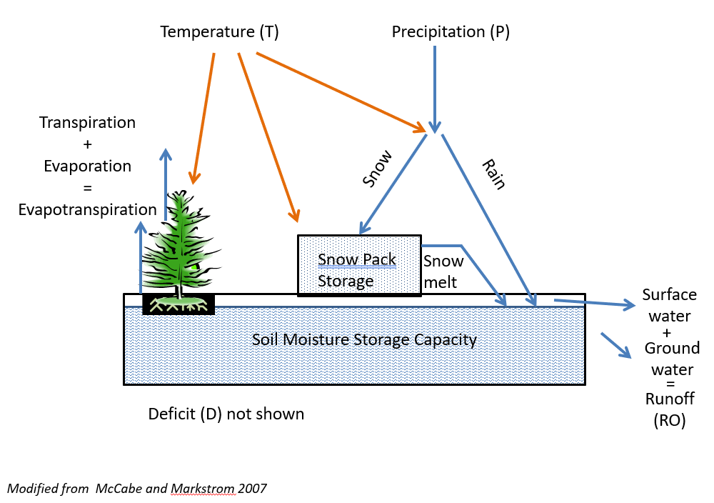

This report is created from temperature and precipitation data that is input to a water balance model. The historical temperature and precipitation data are from [gridMET](http://www.climatologylab.org/gridmet.html). The future climate projections, inmcm4 RCP 4.5 and HadGEM2-CC365 RCP 8.5, are from the [CMIP5 experiments](https://www.wcrp-climate.org/wgcm-cmip/wgcm-cmip5) . The water balance model is maintained by the National Park Service (Mike Tercek, David Thoma and John Gross). Collectively this report summarizes historical and projected biophysical environmental conditions from 1980-2100 at the single grid cell level (gridMET = 4km; projections = 1km). A link to the NPS water balance gridded products an be found [here](http://www.yellowstone.solutions/thredds/catalog.html).

## Annual values through time

The variables of runoff, rain, potential evapotranspiration (PET), actual evapotranspiration (AET), and deficit are summed to show annual values through time. Accumulated snow water equivalent (SWE) shows the max value for the year regardless of the month it occurs in. Accumulated growing degree days (AGDD) starts accumulating on October 1 of the previous year, and the max value is taken at its highest point. Soil water shows the mean value for the year.

The reason for the different summary statistics is because hydrologist use these variables in different ways. Water variables that don’t have an upper limit like rain, runoff, evapostranspiration and deficit can accumulate indefinitely within a calendar year, whereas soil moisture is limited by the soil water holding capacity so it is averaged on an annual basis. Temperature variables are averaged by convention and growing degree days are summed to account for the seasonal accumulation of heat that controls biological metabolism and thus growth rates and phenology when water is available. For the variables that are accumulated, we take the max of the variable because it is already a summation of the total through the year.

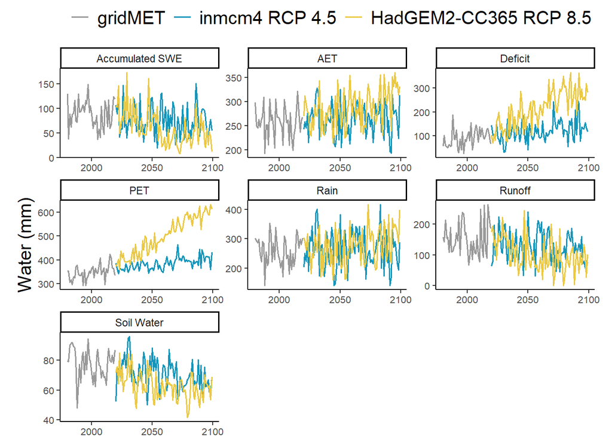

Figure 1. Annual averages over time. The gray line represents historical data modeled from gridMET climate data, the turquoise line represents inmcm4 rcp45 and the yellow line represents HadGEM2-CC365 rcp85

## Deficit v. Actual Evapotranspiration (AET)

Deficit (D) and actual evapotranspiration (AET) represent unmet water needs of vegetation and vegetation water use. They are good predictors of vegetation type, and are useful variables in understanding climate stress on vegetation and how vegetation may transition in the future (Stephenson, 1998). If the clustering of AET and deficit change in climate space, vegetation assemblages will respond and changes in assemblages will eventually reflect the new climate space. The figure below (from Stephenson) shows how AET v. D differs across bioregions in the U.S.

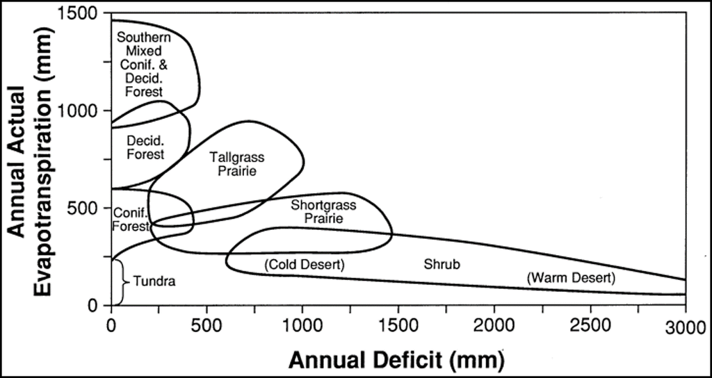

Figure 2. Stephenson (1998)

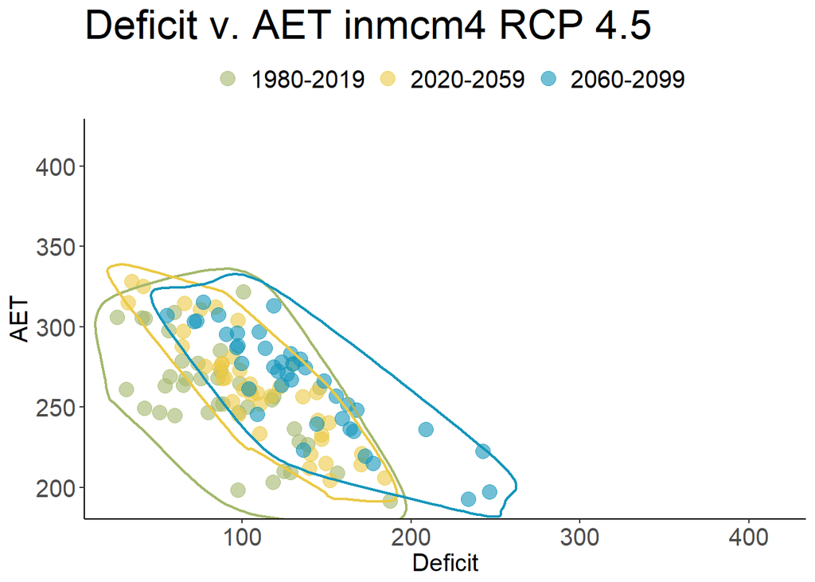

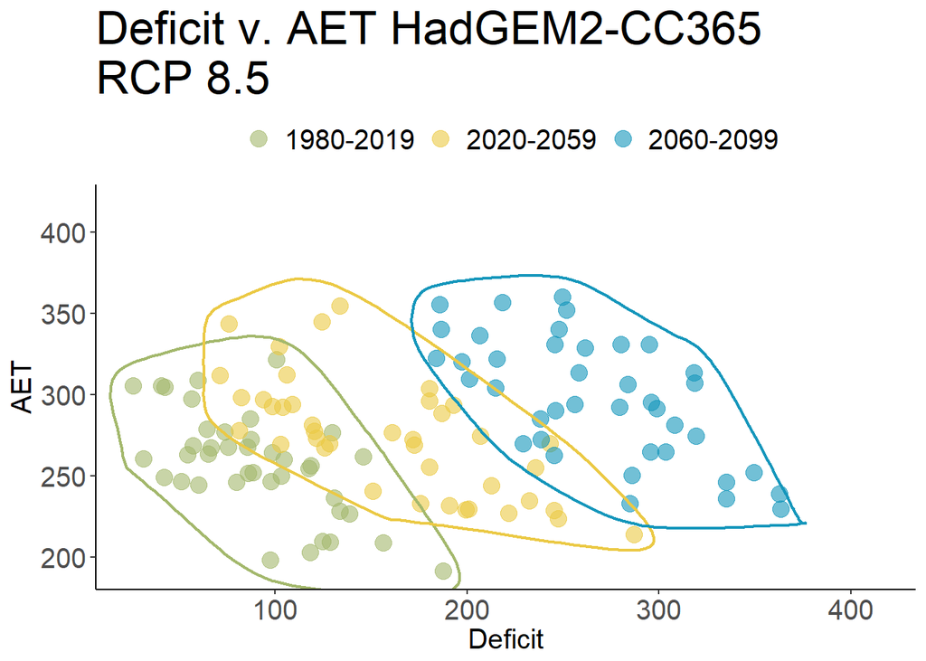

Figure 3. Modeled Deficit vs. AET. The points are annual sums of daily observations in each year. The green points represent 1980-2019; the yellow points 2020-2059; and the turquoise points 2060-2099. The contours around each set of points encircle the climate space for inmcm4 rcp45 and HadGEM2-CC365 rcp85.

## Soil Water

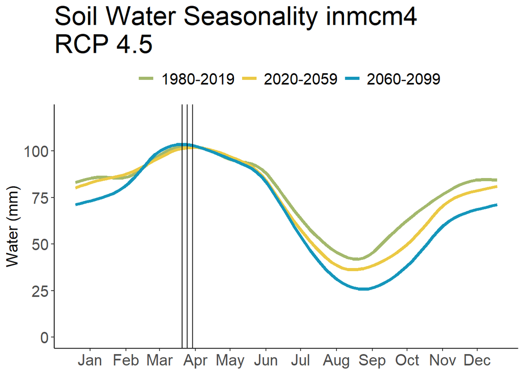

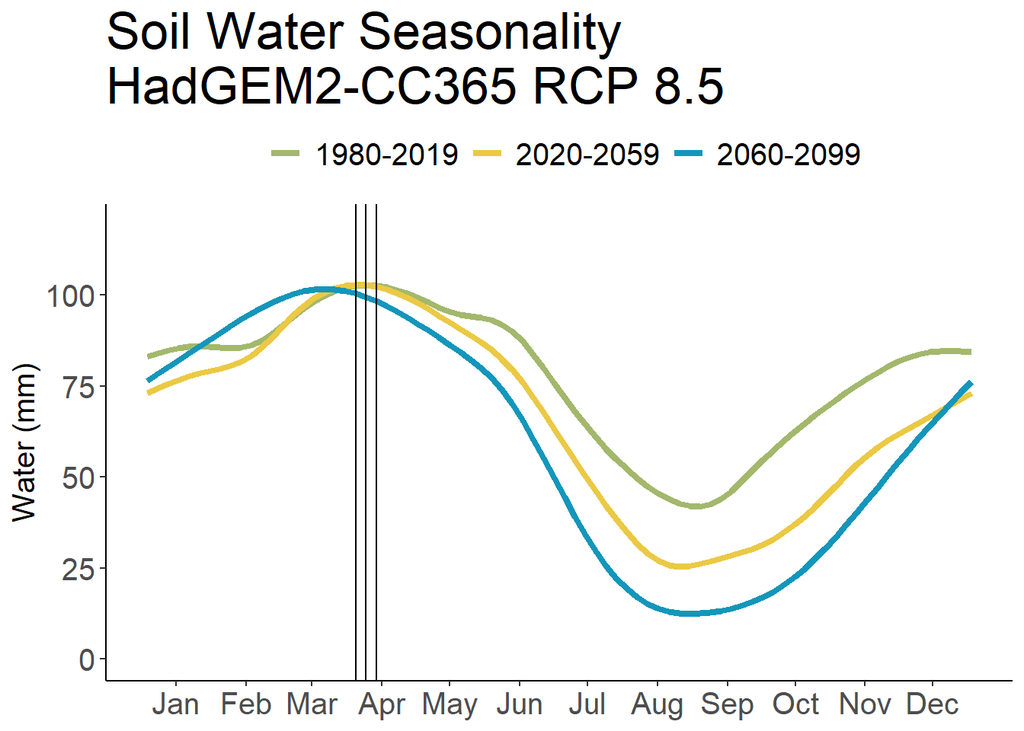

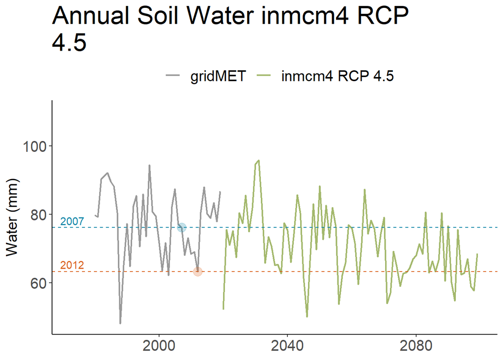

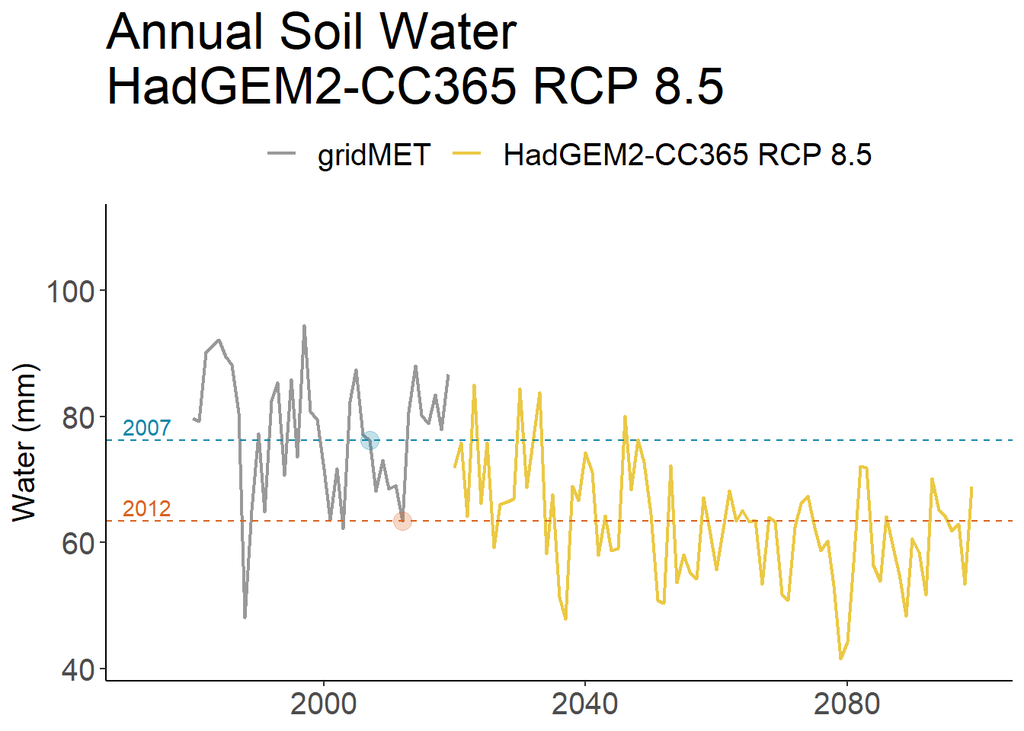

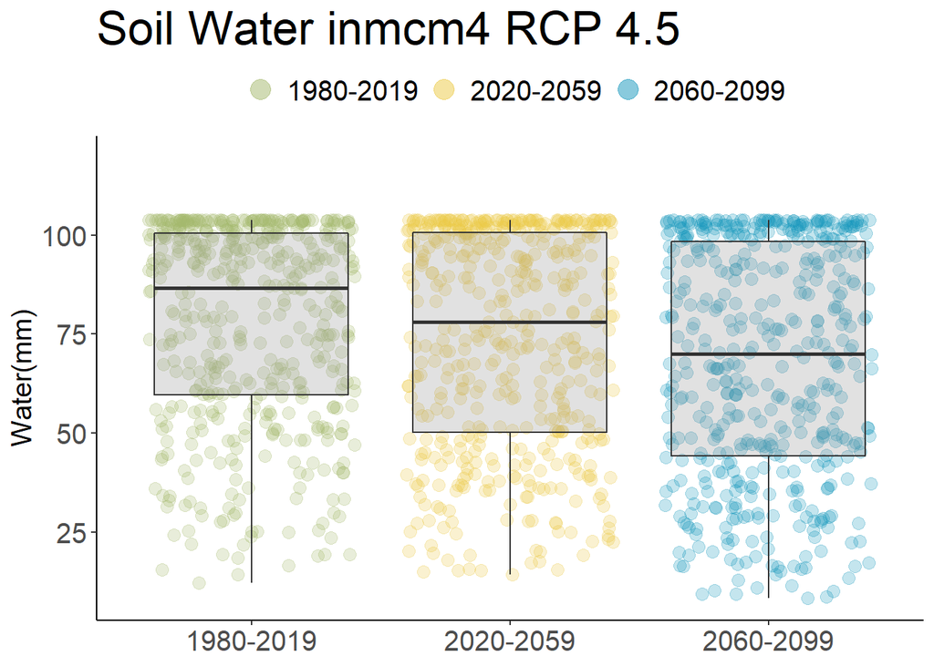

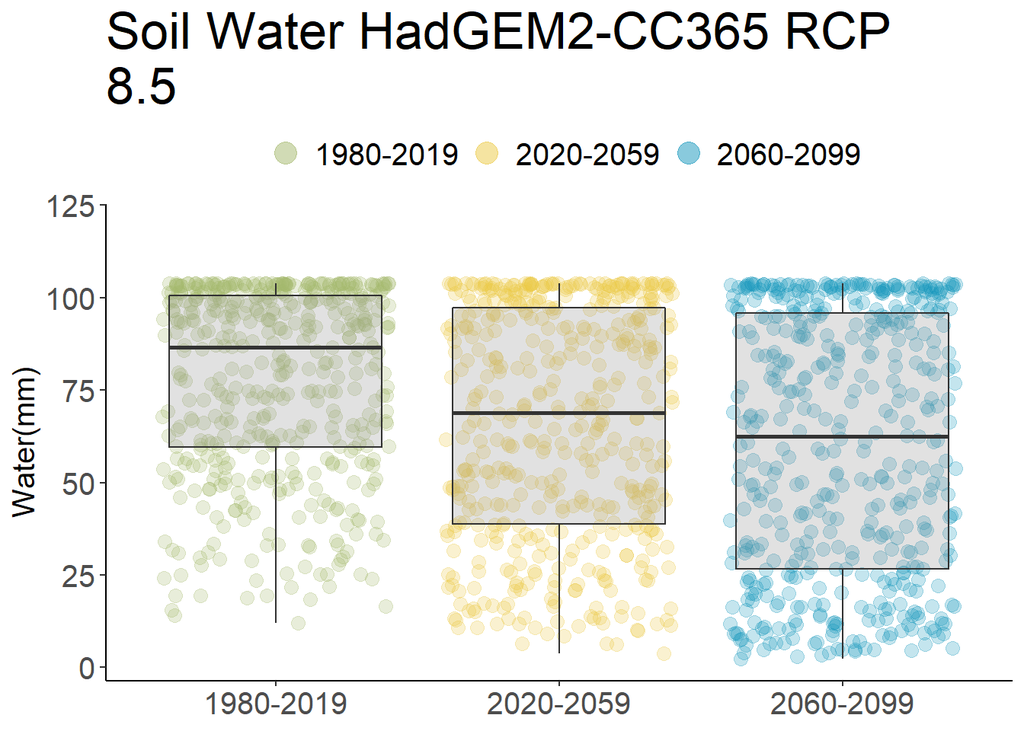

## Runoff

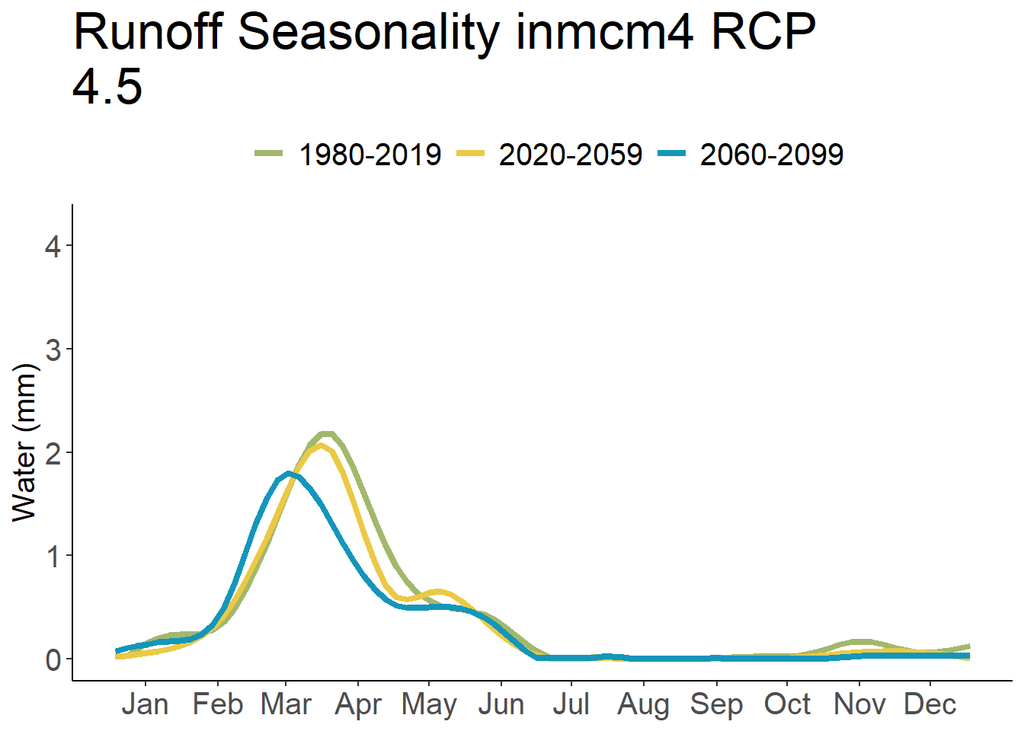

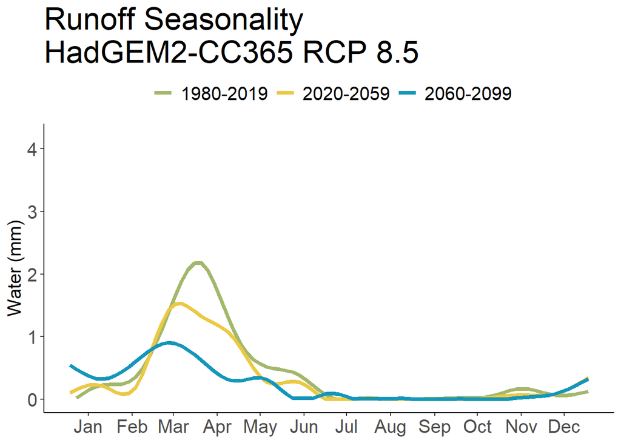

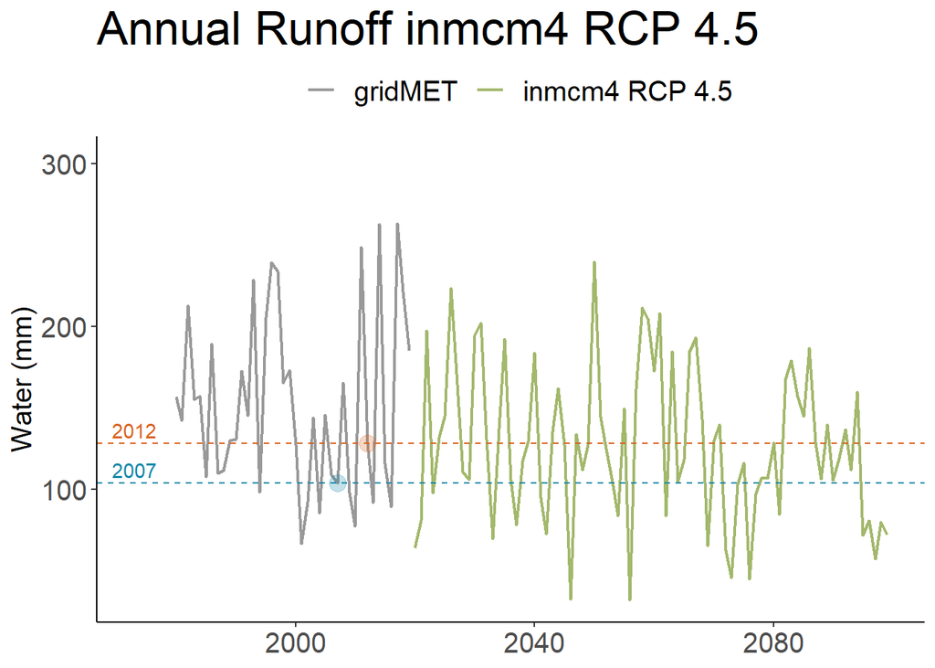

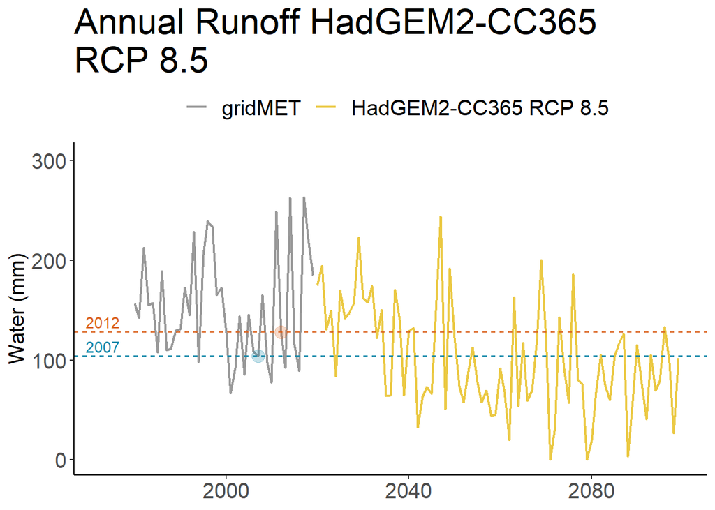

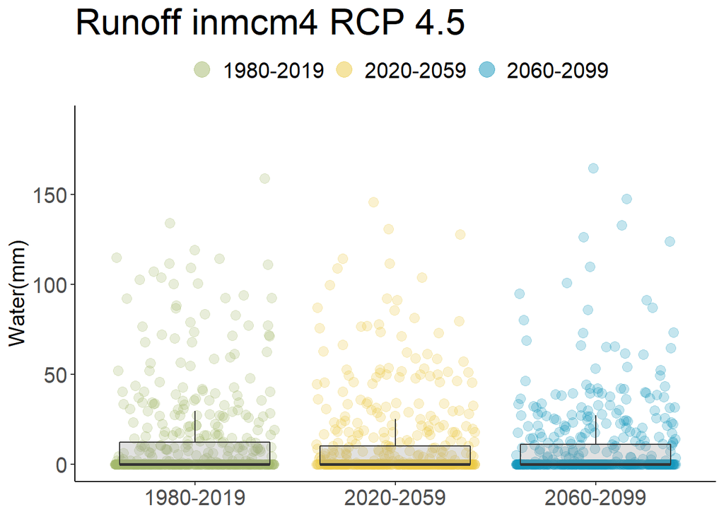

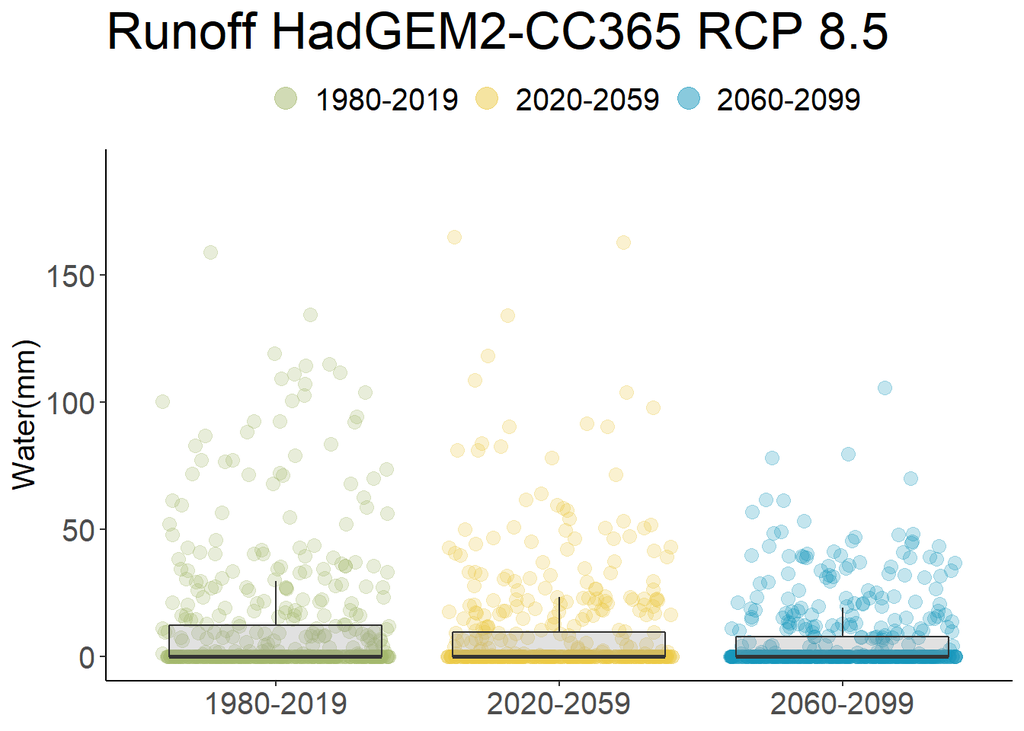

## Rain

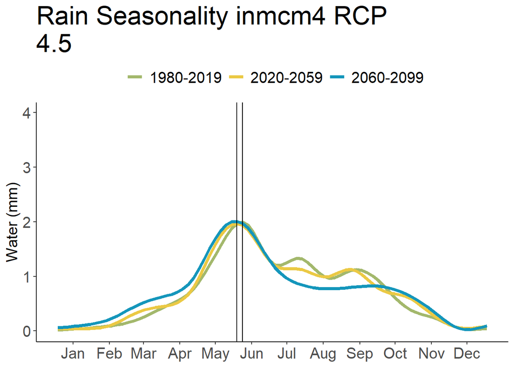

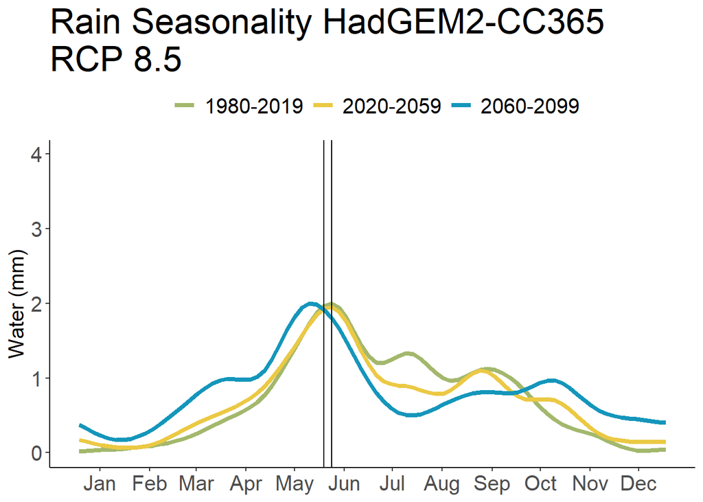

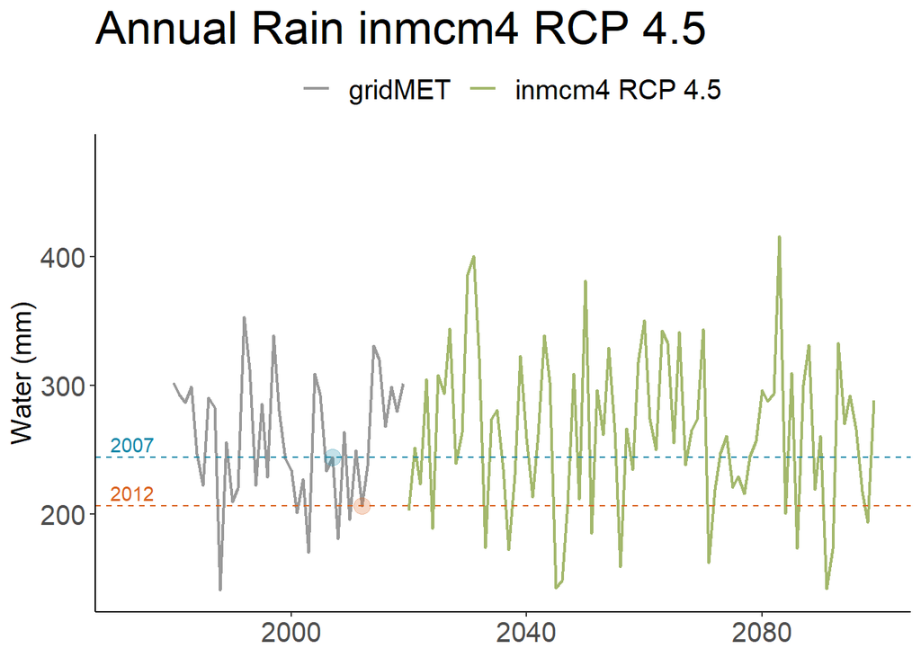

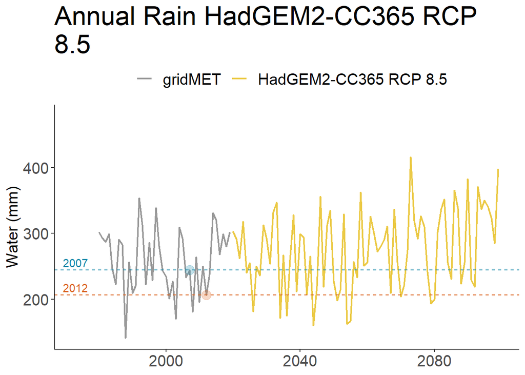

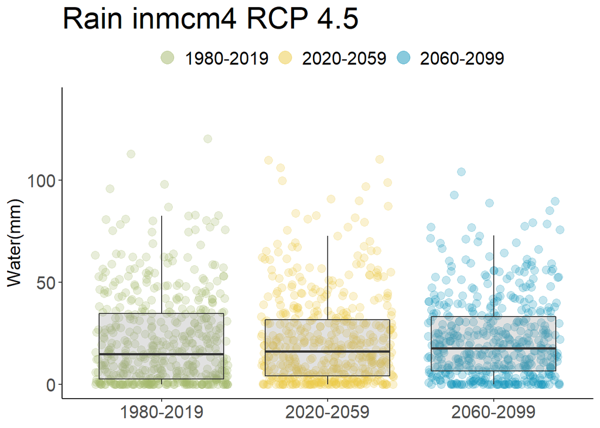

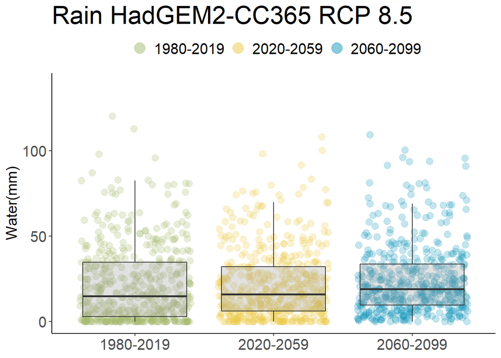

## Accumulated Snow Water Equivalent (SWE)

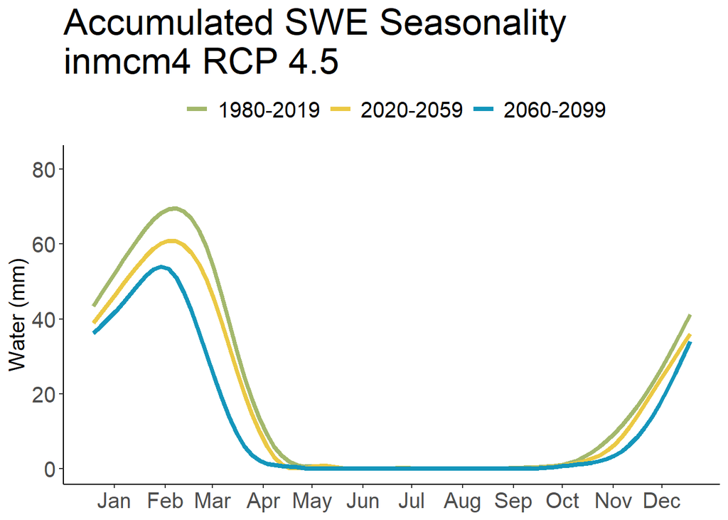

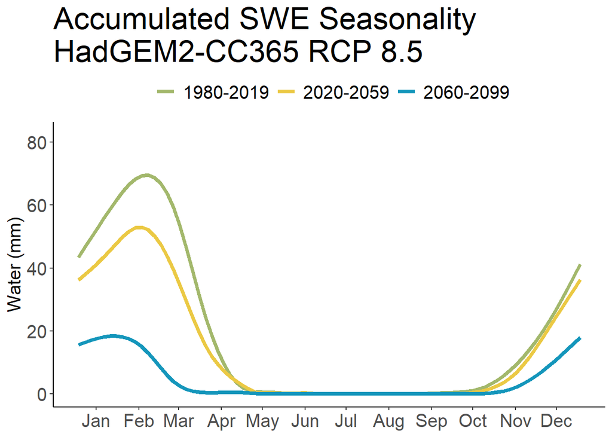

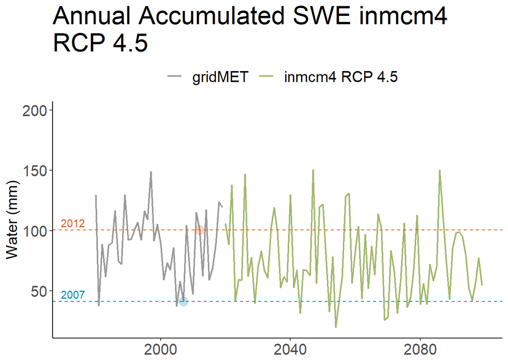

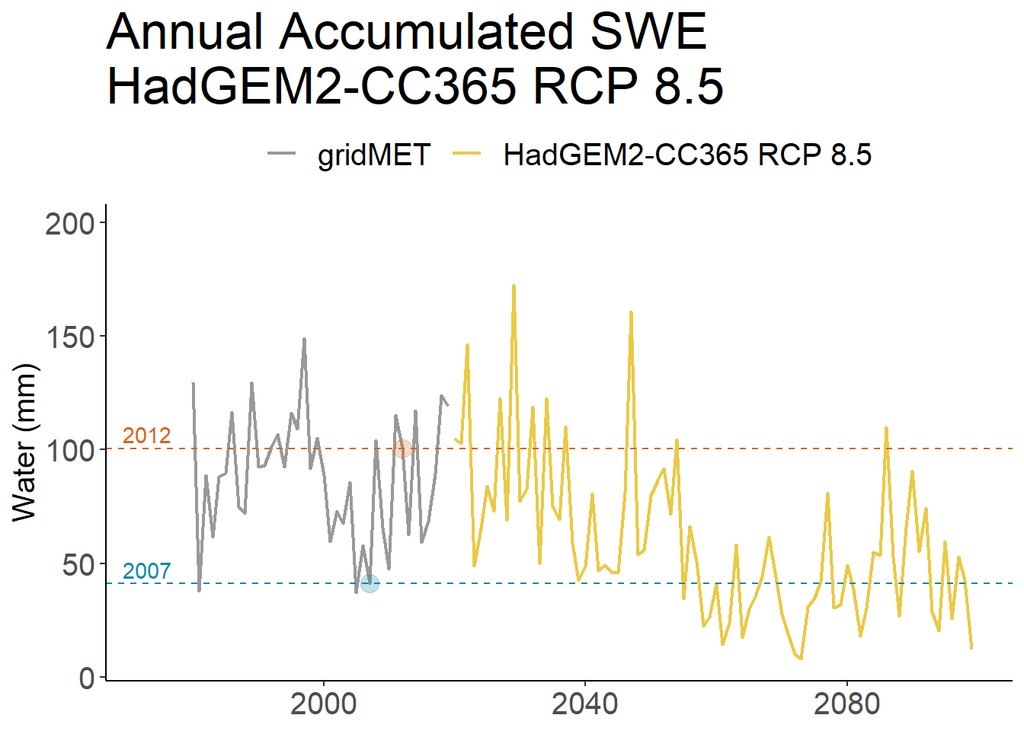

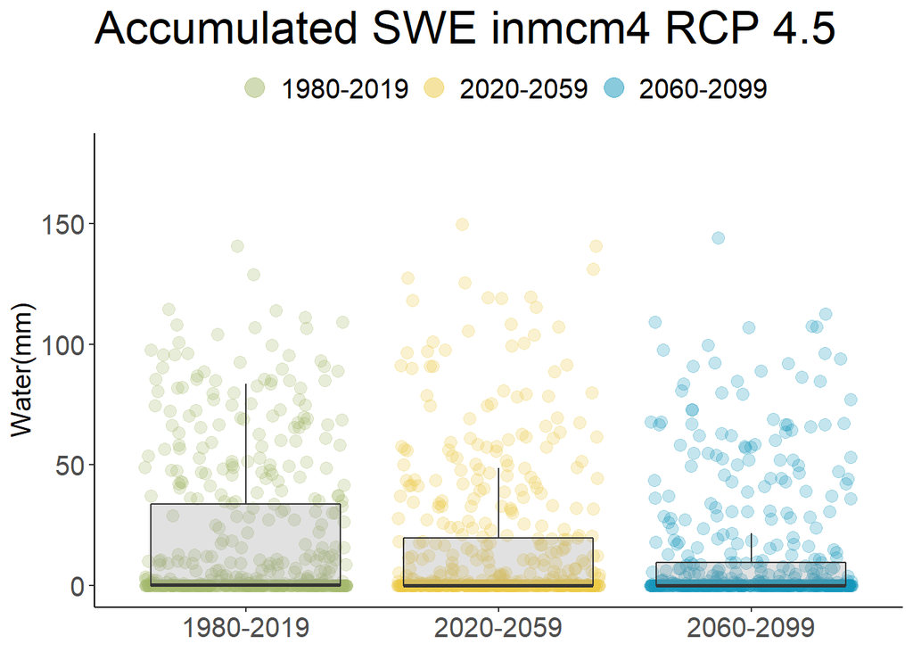

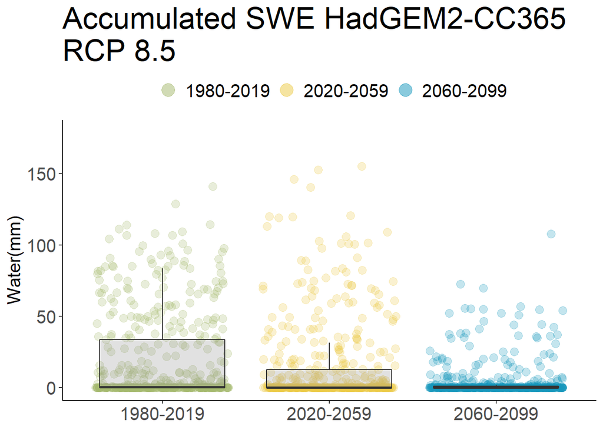